## My Peer review 1

The data used in this study is a personal activity monitoring device. This device collects data at 5 minute intervals through out the day. The data consists of two months of data from an anonymous individual collected during the months of October and November, 2012 and include the number of steps taken in 5 minute intervals each day.

```r
# Define some options for knitr
knitr::opts_chunk$set(tidy=FALSE, fig.path='figures/')

# Load the data w/ relative filepath
activity<-read.csv(file="C:/Users/james_000/Documents/R/ActiveData/activity.csv",stringsAsFactors=FALSE)

# Change the date variable to proper class
activity$date<-as.Date(activity$date)
```

The dataset is in a csv file format. There are three variables included in this dataset:

- steps (`steps`): Number of steps taking in a 5-minute interval (missing values are coded as NA)
- date (`date`): The date on which the measurement was taken in YYYY-MM-DD format
- interval (`inteval`): Identifier for the 5-minute interval in which measurement was taken

Here is a sample of the data:

```r
# First 5 data
head(activity)
```

```
##   steps       date interval
## 1    NA 2012-10-01        0
## 2    NA 2012-10-01        5
## 3    NA 2012-10-01       10
## 4    NA 2012-10-01       15
## 5    NA 2012-10-01       20
## 6    NA 2012-10-01       25
```

## What is the mean number of steps taken per day?

```r
# First, let's summarize the total steps taken by day without the NA values
totalsteps<-aggregate(formula=steps~date,data=activity,FUN=sum,na.rm=TRUE)

# Mean
meansteps<-mean(totalsteps$steps)

# Median
mediansteps <- median(totalsteps$steps)
```

The subject took a mean of 1.0766 × 10<sup>4</sup> and a median of 10765 per day. The number of steps taken daily by the subject is summarized in the histogram below:

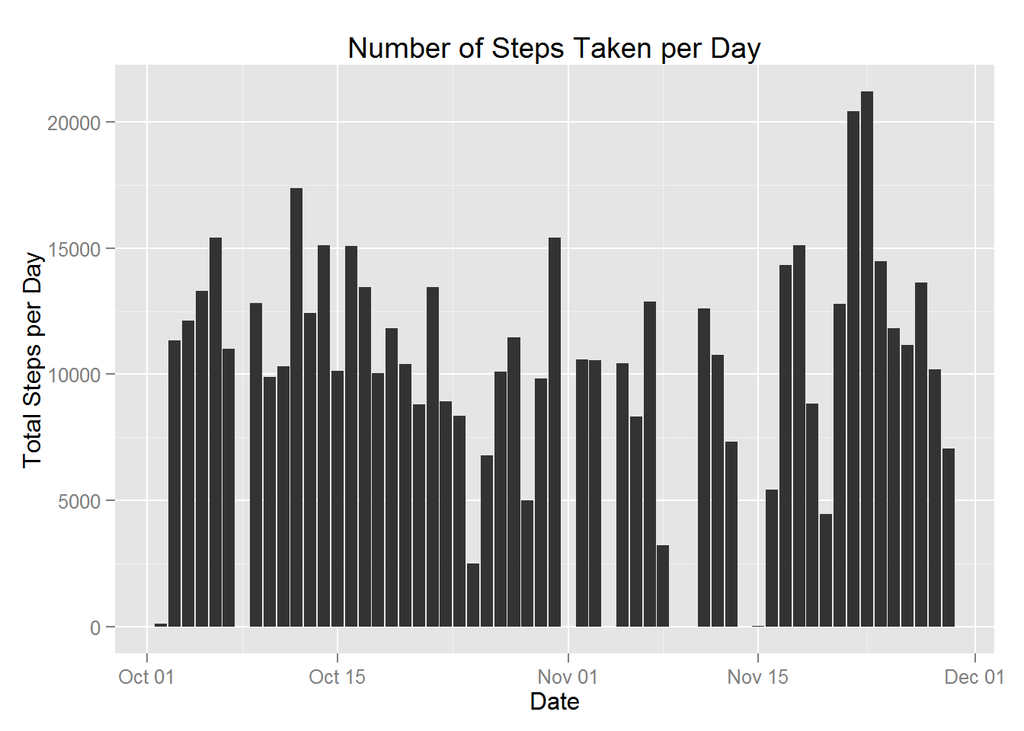

```r
# Create a histogram using ggplot2
library(ggplot2)
qplot(x=date, y=steps,data=subset(activity, complete.cases(activity)),stat='summary', fun.y=sum, geom='bar') +
        labs(title='Number of Steps Taken per Day',
        y='Total Steps per Day', x='Date')
```

## What is the average daily activity pattern?

To answer thiis question, we will find the mean steps taken each interval.

```r
# Summarize the data with mean steps per interval
activity_interval<-aggregate(formula= steps~interval,data=activity,FUN=mean,na.rm=TRUE)

# Finding which interval has the max # of steps
max_steps<-activity_interval[which(activity_interval$steps==max(activity_interval$steps)),]
```

The interval labelled as 835 (the 104th interval of each day) contains the max number of steps averaged across all the days sampled: 206.1698. The following figure will show the average number of steps taken during each interval:

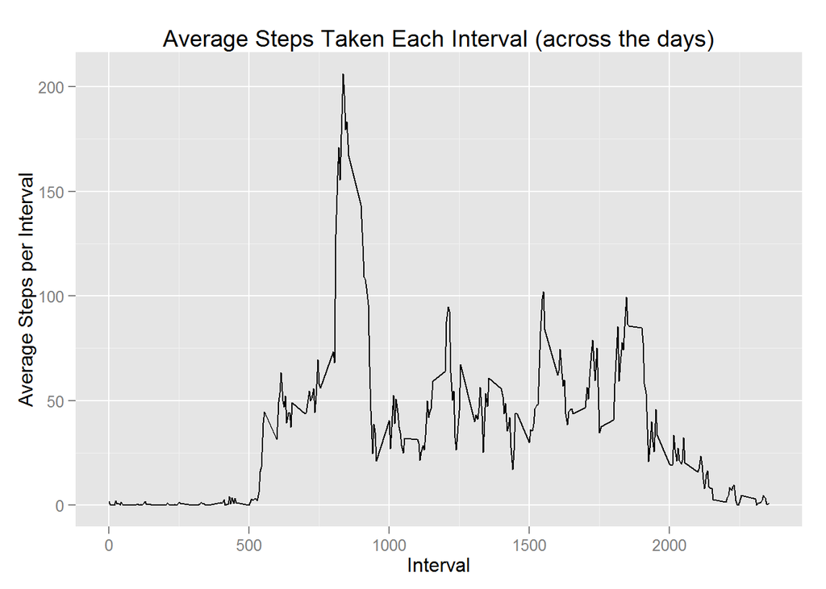

```r
steps_per_interval<-qplot(x=interval,y= steps,data=subset(activity,complete.cases(activity)),stat='summary',fun.y=mean,geom="line") +
        labs(title='Average Steps Taken Each Interval (across the days)',y='Average Steps per Interval', x='Interval')

steps_per_interval
```

## Imputing missing values

```r
# Counting the number of missing values
NAtotal<- sum(!complete.cases(activity))
stepNAs<-sum(is.na(activity$steps))
dateNAs<-sum(is.na(activity$date))
intervalNAs<-sum(is.na(activity$intervals))
```

The dataset contains a total of 2304 missing values. 2304 are steps, 0 are dates, and 0 are intervals. Clearly showing that only steps were not recorded at times.

### Inputation strategy

Without doing any additional analysis, I believe there seems to be more variation in the steps taken per day, than the steps taken at intervals looking at the graphs above. Using this assumption, I will complete the missing cases with the average number of steps from the corresponding interval (with rounding to avoid fractional steps).

```r
# Adding a column to the previously calculated means w/ rounded steps
activity_interval$input<-floor(activity_interval$steps)

# Merge this with the dataset
inputactivity<-merge(activity,activity_interval[,c('interval','input')],by='interval')

# Replacing the NA values
inputactivity$steps<- ifelse(is.na(inputactivity$steps),inputactivity$input,inputactivity$steps)

# Remove the inputed column
inputactivity<-inputactivity[,1:3]
```

```r
# Sum of steps per date
input_totalsteps<-aggregate(formula=steps~date,data=inputactivity,FUN= sum)

# Mean
mean_inputsteps<-mean(input_totalsteps$steps)
# Median
median_inputsteps<-median(input_totalsteps$steps)
```

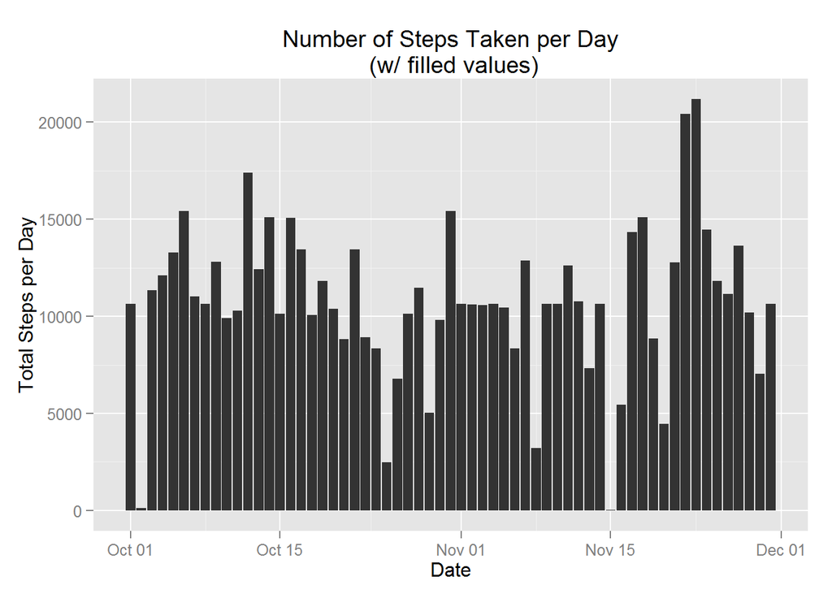

```r
qplot(x=date, y=steps,data=inputactivity,stat='summary', fun.y=sum, geom='bar') +
        labs(title='Number of Steps Taken per Day\n (w/ filled values)',
        y='Total Steps per Day', x='Date')
```

## Are there differences in activity patterns between weekdays and weekends?

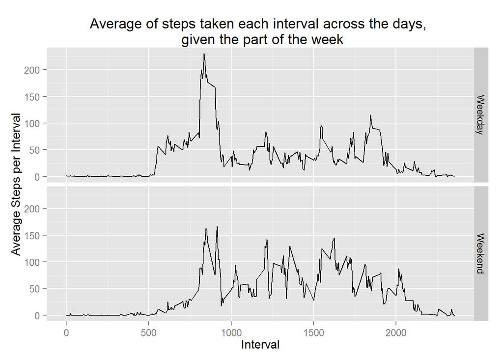

```r
# Add a column in the dataset that distinguishes weekday from weekend using weekdays()
inputactivity$week<-ifelse(weekdays(inputactivity$date)!="Saturday"& weekdays(inputactivity$date)!="Sunday","Weekday","Weekend")


# Create the plot
steps_per_interval %+% inputactivity + facet_grid(week~.) +
  labs(title='Average of steps taken each interval across the days, \n given the part of the week')
```